# Political Ideology of Candidate Ratings

Group J: Lydia Sheyda, Mirella Hernandez, & Julia Lee

5/6/2018

# Abstract:

Partisanship plays an increasingly large role in today’s elections. In order to help voters decide, various organizations have for a long time rated candidates for public office. However, as the country has become more polarized, so have these rating organizations. The question is whether these ratings are actually examining a candidate’s qualification and fitness for office, or merely reflecting one party’s interests or the other.To determine the usefulness of these ratings, we created a multiple regression model to see how the scores are related to each other and a multiple logistic model to see how the ratings of these groups are related to a lawmaker’s political party. We found that these scores are highly correlated and good predictors for a politician’s party. We conclude that these scores are partisan and perhaps not helpful for voters.

# Introduction:

Studies have shown that the growing political divide in this country has caused an increase in partisan voting and the last presidential election confirmed the increasingly important role of partisanship [2]. In 2016, the polling data show that a large group of people lined up behind their party, with 89 percent of Democrats voting for Hillary Clinton and 88 percent of those who identified as Republicans voting for Trump [2]. Those large numbers indicate that rather than making an individual decision about the qualifications of the candidates, voters are choosing to defer to their parties [3]. Growing partisanship means that often people vote blindly, even when there exist contradictions in their belief systems [2]. Candidate ratings were developed to help voters to make educated decisions and to be less swayed by irrelevant news events and short-term emotions around the time of the election [4].

In today’s complex political landscape, hundreds of groups are actively giving ratings to lawmakers in the United States [6]. As the 2018 midterm elections approach, it would be good to see how useful these ratings are to voters. Frequently, different lobbying groups give politicians ratings on issues to educate voters on candidates [6]. These candidate ratings are often assigned to lawmakers based on various criteria that may be highly subjective and vary between groups. Frequently used criteria include: “voting records, political ideology, and campaign contributions”[6]. The politics and self interests of these lobbying groups cover the whole gamut of the political spectrum [6] but some of these groups also pride themselves in being non-partisan [7]. These candidate ratings and scores from lobbying organizations and activists groups have a complex history in the American political landscape [6]. Often these ratings were created by groups to advance their own political interests [7]. But which of the many ratings are the most informative to American voters? Which of these ratings are the most partisan? How should voters read these readings [7]?

Based on prior knowledge we predict that the scores from the Americans for Democratic Action (ADA) and the Children’s Defense Fund (CDF) will have a positive association with a lawmaker’s probability of being a Democrat] and that there will be a positive association with American Civil Liberties Union (ACLU) score.[6] Americans For Tax Reform (ATR) is a conservative grassroots lobbying organization that seeks to reduce taxation in all levels of government, founded by conservative and influential lobbyist Grover Norquist, so we predict that its ratings will have a negative association with a lawmaker’s probability of being a Democrat and a negative association with ACLU score.

We want to know if the different ratings are highly partisan, and if this is the case then it would indicate that the scores are not very useful to voters [7]. If we see a group has a strong association with party, we might want to take its ratings with a grain of salt [6]. We also want to see if knowing the rating group could tell us the rating of a different group. The questions we want answered are: how are these scores related to each other and how can voters use these scores to predict a candidate’s political ideology.

# Data:

To answer some of these questions we used data collected by California Polytechnic State University. The dataset contains the scores given to the members of the U.S. Congress by some liberal and conservative advocacy groups for the year of 2007. For our purposes we filtered out the 79 cases that had missing values for a total of 348 useable cases. While there are 20 variables in the original dataset, we narrowed it down to 9 variables that we wanted to look at. We kept the scores of organizations that were more well-known and had more members because their scores are more publicized and we kept the party variable because there seems to be a partisan weight to the scores. We wanted to investigate how these scores are related to each other so we looked at how these scores can be used to predict ACLU scores. We also wanted to see how partsian are these scores so we looked at how these scores are related to the probability of being a Democrat.

We will examine the political parties of politicians. While there are many political parties, there are 2 major political parties in the U.S. The two major parties are The Republican party and The Democratic Party. The Republican Party is the conservative right leaning political party in the U.S. and the Democratic Party is the liberal left leaning political party. In our data set all the lawmakers belonged to either of these two parties. To create a logistic model of probability, we created a binary variable called isDemocrat where 0 means the individual is a Republican and 1 means that they are a Democrat. We will also look at the scores by American Conservative Union, American Civil Liberties Union (ACLU), Children’s Defense Fund(CDF), Americans for Tax Reform (ATR), Americans for Democratic Action (ADA), Traditional Values Coalition (TVC), NAACP; all of these scores range from 0 -100.

```r
voter_guide<-read_csv("~/GROUP_J_DATA.csv")
voter_guide
```

```r
#Data Exploration
str(voter_guide)
head(voter_guide)
names(voter_guide)
glimpse(voter_guide)
```

```r
#making sure numeric variables are treated as numeric
voter_guide$NARAL <-as.integer(voter_guide$NARAL)
voter_guide$FRC <-as.integer(voter_guide$FRC)
voter_guide$SEIU <-as.integer(voter_guide$SEIU)
voter_guide$CDF<-as.integer(voter_guide$CDF)
voter_guide$Eagle<-as.integer(voter_guide$Eagle)
voter_guide$ACLU<-as.integer(voter_guide$ACLU)
voter_guide$ATR <- as.integer(voter_guide$ATR)
voter_guide$Club4 <-as.integer(voter_guide$Club4)
voter_guide$Liberal_mean<-as.integer(voter_guide$Liberal_mean)
voter_guide$ACU<-as.integer(voter_guide$ACU)
voter_guide$Conservative_mean<-as.integer(voter_guide$Conservative_mean)
voter_guide$NAACP<-as.integer(voter_guide$NAACP)
voter_guide$TVC<-as.integer(voter_guide$TVC)
voter_guide$CWA <-as.integer(voter_guide$CWA)
#making party variable binary numeric
voter_guide<-voter_guide%>%
  mutate(isDemocrat = ifelse(Party %in% c("R"),0,1))
voter_guide$isDemocrat <-as.numeric(voter_guide$isDemocrat)

voter_guide_clean<-voter_guide %>%
    na.omit() %>%
select(-Liberal_mean, -Conservative_mean, -RTL,-Club4, -CWA, -NARAL, -SEIU, -FRC, -CD, -Eagle, -Rep,CDF, ATR, ADA, TVC, Party, ACU, NAACP, isDemocrat, ACLU)
names(voter_guide_clean)
```

# Methods:

To test these hypotheses, we built models using different methods to see possible associations. We first used stepwise regression to get a model of best fit to predict ACLU score. We created a regression model to try to predict the ACLU scores of lawmakers using political party, Score by American Conservative Union (ACU), Americans for Tax Reform (ATR), Americans for Democratic Action (ADA), Traditional Values Coalition (TVC), and the NAACP. We did this to see which of these factors are associated with ACLU when adjusted for the others. Our reference variables for the model is when Party = Democrat. We then checked our L.I.N.E conditions for the model. Because the conditions did not seem to be met, we first looked at the ANOVA output and then did a bootstrap distribution for the coefficients of the predictors and created 95% confidence intervals to see if our predictors were individually statistically significant. We also wanted to see how highly correlated our predictors in the model were so we looked at correlation and VIF. We then saw if we could drop some predictors in our model to fix multicollinearity. Next we performed an ANOVA test to see if the mean ACLU score for a lawmaker is statistically different depending on a lawmakers political party.

# Basic descriptive statistics/summary statistics:

```r
favstats(voter_guide_clean$ATR)
```

```
##  min Q1 median Q3 max     mean       sd   n missing
##    0 14   61.5 95 100 53.26724 40.43696 348       0
```

```r
favstats(voter_guide_clean$TVC)
```

```
##  min Q1 median Q3 max     mean       sd   n missing
##    0 14     57 85 100 50.75287 31.51701 348       0
```

```r
favstats(voter_guide_clean$NAACP)
```

```
##  min Q1 median Q3 max     mean       sd   n missing
##    8 32     74 96 100 64.98851 31.76335 348       0
```

```r
favstats(voter_guide_clean$ADA)
```

```
##  min Q1 median Q3 max     mean       sd   n missing
##    0 10   62.5 95 100 54.41092 39.37568 348       0
```

```r
favstats(voter_guide_clean$ACLU)
```

```
##  min Q1 median  Q3 max     mean       sd   n missing
##    0  0     50 100 100 49.78161 45.67727 348       0
```

```r
favstats(voter_guide_clean$CDF)
```

```
##  min Q1 median  Q3 max     mean       sd   n missing
##    0 30     75 100 100 65.05747 34.95979 348       0
```

# Results:

```r
#MLR
full <- lm(ACLU~., data=voter_guide_clean)
fullMSE<-(summary(full)$sigma)^2
null <- lm(ACLU~1, data=voter_guide_clean)
step(null, data=voter_guide_clean, scope=list(lower=null, upper=full),scale=fullMSE, direction = "both" )
```

```r
mod2 <-lm(ACLU ~ ATR  + ADA  + TVC  + Party + ACU + NAACP , data = voter_guide_clean)
summary(mod2)
```

```
##
## Call:
## lm(formula = ACLU ~ ATR + ADA + TVC + Party + ACU + NAACP, data = voter_guide_clean)
##
## Residuals:
##     Min      1Q  Median      3Q     Max
## -35.598  -3.554  -0.705   3.242  37.112
##
## Coefficients:
##              Estimate Std. Error t value Pr(>|t|)
## (Intercept)  93.14975    5.28723  17.618  < 2e-16 ***
## ATR          -0.11608    0.06625  -1.752 0.080638 .
## ADA           0.29294    0.08770   3.340 0.000930 ***
## TVC          -0.18480    0.04834  -3.823 0.000157 ***
## PartyR      -29.90317    4.12276  -7.253 2.76e-12 ***
## ACU          -0.38408    0.06900  -5.566 5.27e-08 ***
## NAACP        -0.14079    0.08325  -1.691 0.091724 .
## ---
## Signif. codes:  0 '***' 0.001 '**' 0.01 '*' 0.05 '.' 0.1 ' ' 1
##
## Residual standard error: 9.131 on 341 degrees of freedom
## Multiple R-squared:  0.9607, Adjusted R-squared:   0.96
## F-statistic:  1391 on 6 and 341 DF,  p-value: < 2.2e-16
```

[figure not shown]

```r
#Checking L.I.N.E Conditions:

#linearity
v_numeric_model<-voter_guide_clean %>%
  select (ACLU,ATR,ADA,TVC,ACU,NAACP)
pairs(v_numeric_model)
```

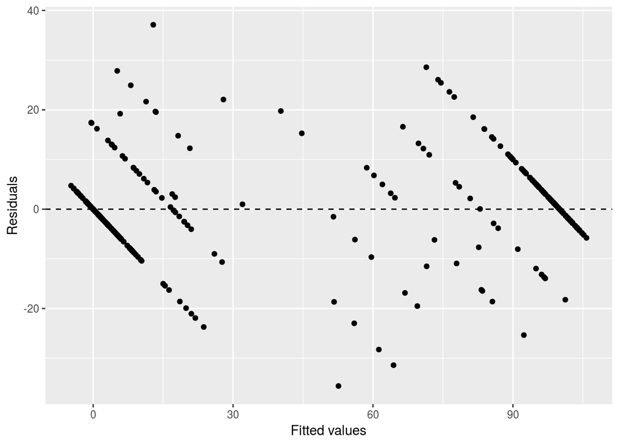

```r
# rvf plot
qplot(x = .fitted, y = .resid, data = mod2) +
  geom_hline(yintercept = 0, linetype = "dashed") +
  xlab("Fitted values") +
  ylab("Residuals")
```

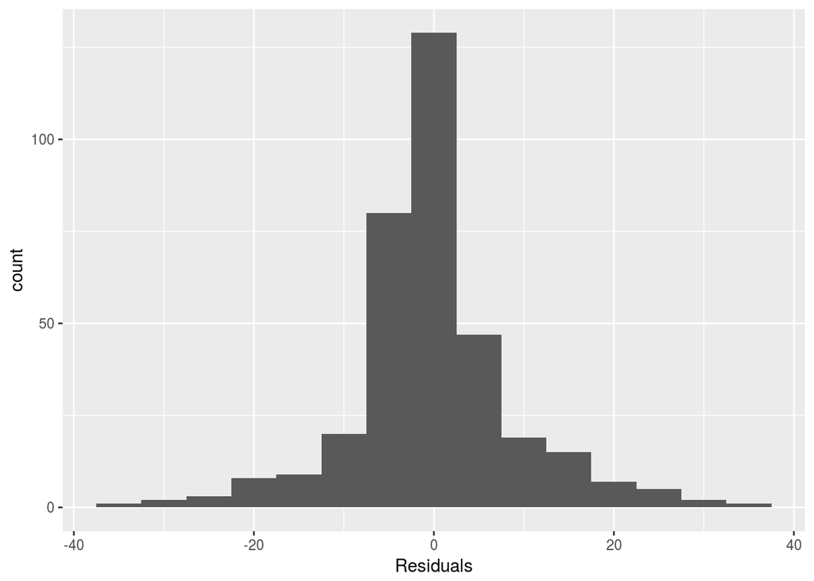

```r
# histogram of residuals
qplot(x = .resid, data = mod2, geom = "histogram", binwidth=5) +
  xlab("Residuals")
```

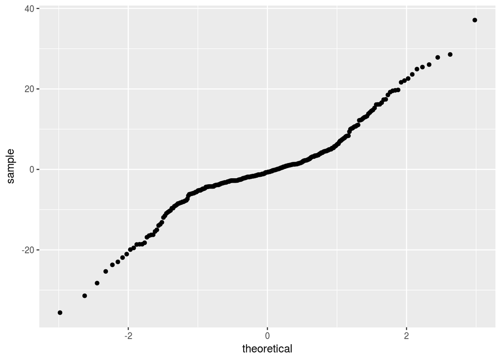

```r
# normal probability plot
qplot(sample = .resid, data = mod2, stat = "qq")
```

Then we checked the L.I.N.E conditions, we saw that the L.I.N.E conditions were not met mainly the equal variance condition. We also saw that linearity was not met. We also don’t know about whether our observations were independent because these scores could influence each other. The validity of t-tests, etc. in MLR models rely on these assumptions that are not be met. So we looked at the ANOVA output, and saw that at least on of the predictors in the model were significant at the 5% level. Looking at the anova output we can see that at least one of a our predictors are statistically significant, F-statistic: 1391 on 6 and 341 DF, p-value: < 2.2e-16. We can see that this model explains 96% of the variability of ACLU scores of lawmakers

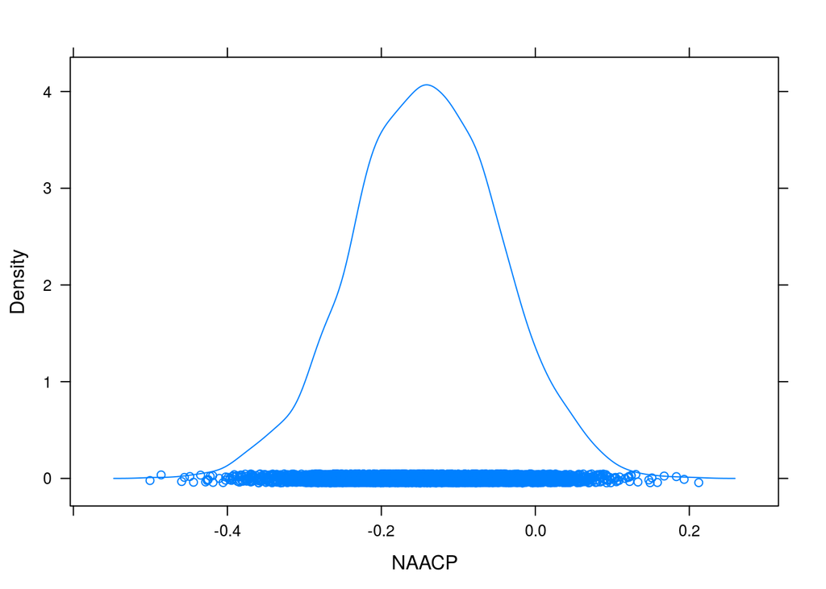

```r
set.seed(123)
fm <- lm(ACLU ~ NAACP, data=voter_guide_clean)
bootstrap <- do(5000) * coef(lm(ACLU~ATR  +  ADA  + TVC  + Party + ACU + NAACP, data=resample(voter_guide_clean)))
p1 <- densityplot(~NAACP, data=bootstrap)
ladd(panel.abline(v=coef(fm)["NAACP"], col="red", lwd=3), plot=p1)
```

```r
z_star <- qnorm(c(0.025, 0.975))
slope <- coef(fm)["NAACP"]
slope + z_star * sd(~NAACP, data=bootstrap)
```

```
## [1] 1.148654 1.524033
```

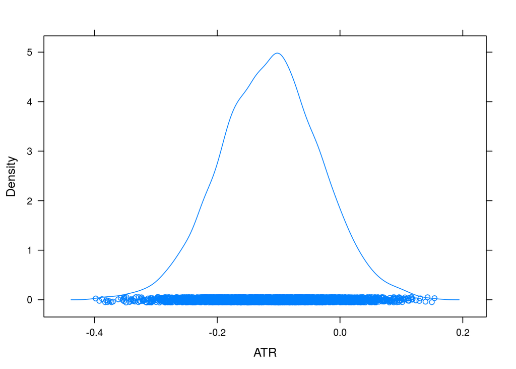

```r
fm2 <- lm(ACLU ~ ATR, data=voter_guide_clean)
p2 <- densityplot(~ATR, data=bootstrap)
ladd(panel.abline(v=coef(fm2)["ATR"], col="red", lwd=3), plot=p2)
```

```r
z_star2 <- qnorm(c(0.025, 0.975))
slope <- coef(fm2)["ATR"]
slope + z_star2 * sd(~ATR, data=bootstrap)
```

```
## [1] -1.2480184 -0.9275892
```

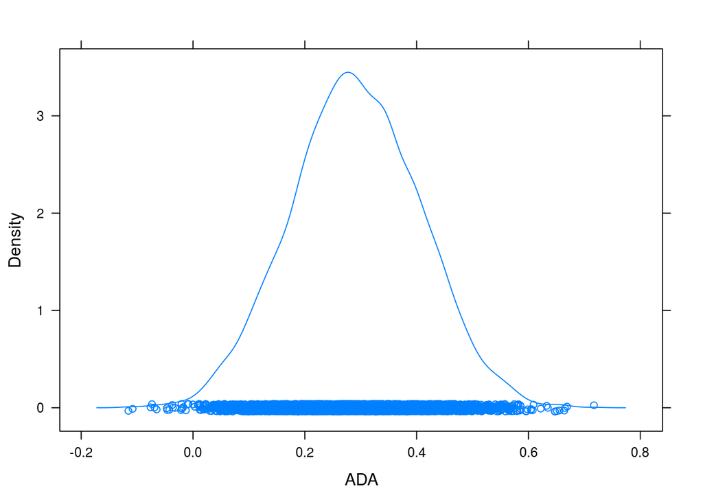

```r
fm3 <- lm(ACLU ~ ADA, data=voter_guide_clean)
p3 <- densityplot(~ADA, data=bootstrap)
ladd(panel.abline(v=coef(fm3)["ADA"], col="red", lwd=3), plot=p3)
```

```r
z_star3 <- qnorm(c(0.025, 0.975))
slope <- coef(fm3)["ADA"]
slope + z_star3 * sd(~ADA, data=bootstrap)
```

```
## [1] 0.8826002 1.3328107
```

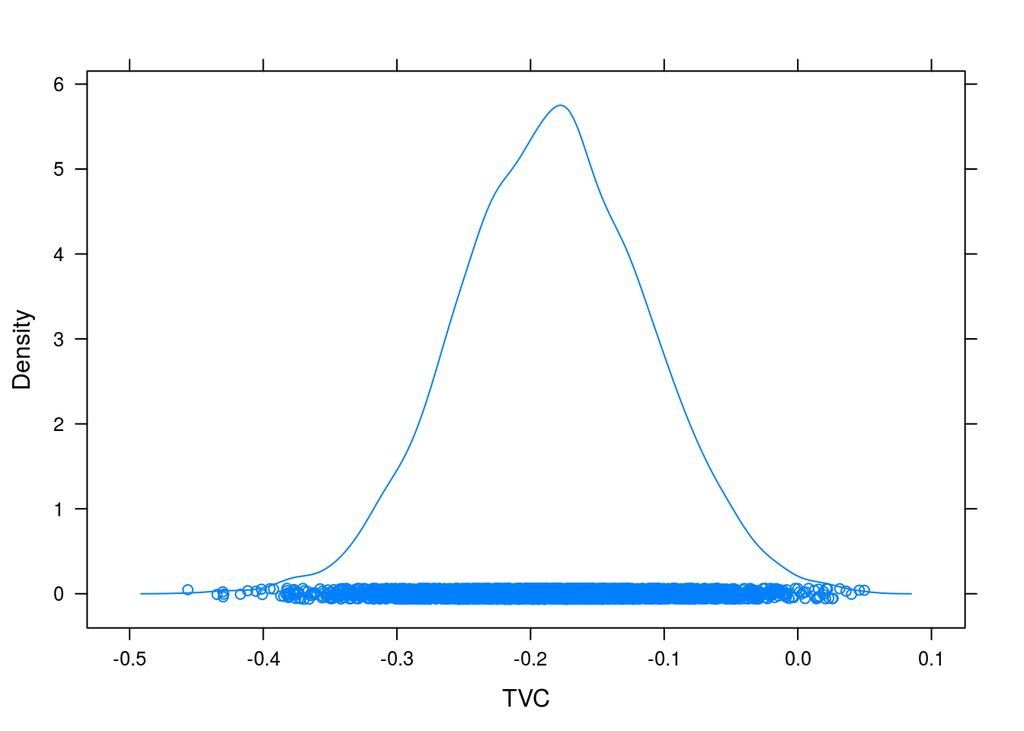

```r
fm4 <- lm(ACLU ~ TVC, data=voter_guide_clean)
p4 <- densityplot(~TVC, data=bootstrap)
ladd(panel.abline(v=coef(fm4)["TVC"], col="red", lwd=3), plot=p4)
```

```r
z_star4 <- qnorm(c(0.025, 0.975))  # 95% CI
slope <- coef(fm4)["TVC"]
slope + z_star4 * sd(~TVC, data=bootstrap)
```

```
## [1] -1.483050 -1.203825
```

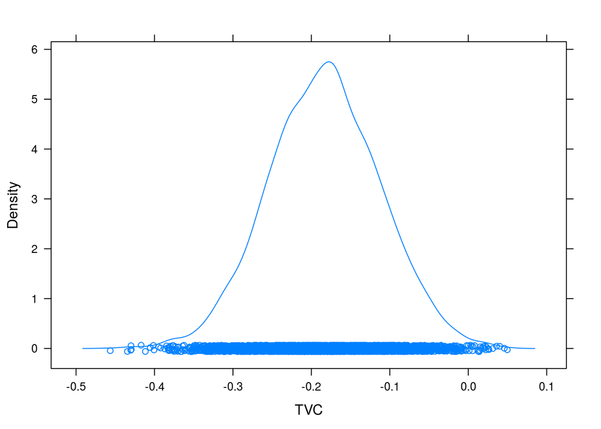

```r
fm5 <- lm(ACLU ~ ACU, data=voter_guide_clean)
p5 <- densityplot(~ACU, data=bootstrap)
ladd(panel.abline(v=coef(fm4)["ACU"], col="red", lwd=3), plot=p4)
```

```r
z_star5 <- qnorm(c(0.025, 0.975))  # 95% CI
slope <- coef(fm5)["ACU"]
slope + z_star5 * sd(~ACU, data=bootstrap)
```

```
## [1] -1.394448 -1.053826
```

```r
#multicolinearity
vif(mod2)
voter_guide %>%
  select(ADA, ATR, ACU, ACLU, TVC, NAACP ) %>%
  cor(use = "complete.obs")
```

[output not shown]

```r
#dropping things from the 1st model to make a 3 variable model
mod_drop <-lm(ACLU ~ TVC + Party + ACU, data = voter_guide_clean)
summary(mod_drop)
```

```
##
## Call:
## lm(formula = ACLU ~ TVC + Party + ACU, data = voter_guide_clean)
##
## Residuals:
##     Min      1Q  Median      3Q     Max
## -36.290  -4.017  -0.961   3.106  41.668
##
## Coefficients:
##              Estimate Std. Error t value Pr(>|t|)
## (Intercept) 107.74654    1.04552 103.056  < 2e-16 ***
## TVC          -0.19423    0.04819  -4.031 6.85e-05 ***
## PartyR      -44.27254    2.21154 -20.019  < 2e-16 ***
## ACU          -0.50832    0.04484 -11.336  < 2e-16 ***
## ---
## Signif. codes:  0 '***' 0.001 '**' 0.01 '*' 0.05 '.' 0.1 ' ' 1
##
## Residual standard error: 9.345 on 344 degrees of freedom
## Multiple R-squared:  0.9585, Adjusted R-squared:  0.9581
## F-statistic:  2649 on 3 and 344 DF,  p-value: < 2.2e-16
```

```r
anova(mod_drop)
```

```
## Analysis of Variance Table
##
## Response: ACLU
##            Df Sum Sq Mean Sq F value    Pr(>F)
## TVC         1 622092  622092 7122.86 < 2.2e-16 ***
## Party       1  60627   60627  694.17 < 2.2e-16 ***
## ACU         1  11222   11222  128.49 < 2.2e-16 ***
## Residuals 344  30044      87
## ---
## Signif. codes:  0 '***' 0.001 '**' 0.01 '*' 0.05 '.' 0.1 ' ' 1
```

```r
vif(mod_drop)
```

```
##       TVC     Party       ACU
##  9.163919  4.871389 10.001669
```

```r
#dropping things again from the 1st model making a two exlpantory  variable model
mod_drop2 <-lm(ACLU ~ TVC + Party, data = voter_guide_clean)
summary(mod_drop2)
```

```
##
## Call:
## lm(formula = ACLU ~ TVC + Party, data = voter_guide_clean)
##
## Residuals:
##     Min      1Q  Median      3Q     Max
## -47.292  -2.073   1.631   1.631  47.927
##
## Coefficients:
##             Estimate Std. Error t value Pr(>|t|)
## (Intercept) 106.7387     1.2191   87.55   <2e-16 ***
## TVC          -0.5978     0.0380  -15.73   <2e-16 ***
## PartyR      -53.8489     2.3918  -22.51   <2e-16 ***
## ---
## Signif. codes:  0 '***' 0.001 '**' 0.01 '*' 0.05 '.' 0.1 ' ' 1
##
## Residual standard error: 10.94 on 345 degrees of freedom
## Multiple R-squared:  0.943,  Adjusted R-squared:  0.9427
## F-statistic:  2854 on 2 and 345 DF,  p-value: < 2.2e-16
```

```r
anova(mod_drop2)
```

```
## Analysis of Variance Table
##
## Response: ACLU
##            Df Sum Sq Mean Sq F value    Pr(>F)
## TVC         1 622092  622092 5200.88 < 2.2e-16 ***
## Party       1  60627   60627  506.86 < 2.2e-16 ***
## Residuals 345  41266     120
## ---
## Signif. codes:  0 '***' 0.001 '**' 0.01 '*' 0.05 '.' 0.1 ' ' 1
```

```r
vif(mod_drop2)
```

```
##      TVC    Party
## 4.160537 4.160537
```

```r
#anova test
anov<-aov(ACLU ~ Party, data = voter_guide_clean)
mod <-aov (ACLU ~ Party, data = voter_guide_clean)
summary(anov)
```

```
##              Df Sum Sq Mean Sq F value Pr(>F)
## Party         1 653109  653109    3188 <2e-16 ***
## Residuals   346  70877     205
## ---
## Signif. codes:  0 '***' 0.001 '**' 0.01 '*' 0.05 '.' 0.1 ' ' 1
```

```r
model.tables(anov)
```

```
## Tables of effects
##
##  Party
##          D      R
##      42.83 -43.82
## rep 176.00 172.00
```

```r
inference(y = ACLU, x = Party, data = voter_guide_clean, statistic = "mean", type = "ht", null = 0,  alternative = "twosided", method = "theoretical")
```

```
## Response variable: numerical
## Explanatory variable: categorical (2 levels)
## n_D = 176, y_bar_D = 92.608, s_D = 16.3105
## n_R = 172, y_bar_R = 5.9593, s_R = 11.9259
## H0: mu_D =  mu_R
## HA: mu_D != mu_R
## t = 56.6627, df = 171
## p_value = < 0.0001
```

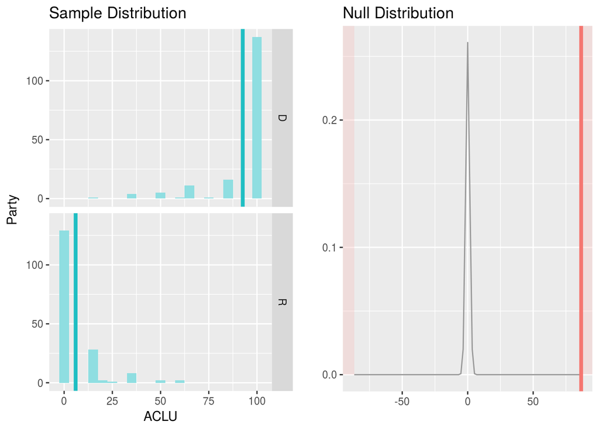

Next we want to see how partisan are some of these scores.We want to find out if there exists a difference between the average ACLU scores based on a politician’s party. So we will conduct a hypothesis test for difference in means. Our null hypothesis is that there exists no difference between the average ACLU and our alternative hypothesis is that there exists a difference between the ACLU Score based on party. Our f-statistic is 3188. Our p-value of our hypothesis test is < 2 x 10^-16, so there is enough statistically significant (at the 5% level) evidence for us to reasonably conclude that there is a difference between the average mean ACLU of lawmakers depending on their political party.

```r
#logistic model
m3 <- glm(isDemocrat~ACLU,family = binomial, data = voter_guide_clean)

m4 <- glm(isDemocrat~. ,family = binomial, data = voter_guide_clean)
m4MSE<-(summary(m4)$sigma)^2
m4null <- glm(isDemocrat~1,family = binomial, data = voter_guide_clean)
step(m4null,data=voter_guide_clean,scope=list(lower=null, upper=full),
     scale=fullMSE, direction= "both")
m5 <- glm(isDemocrat~ ACLU+ADA,family = binomial, data = voter_guide_clean)
m6 <-glm(isDemocrat~ ACLU+ADA+NAACP, family = binomial, data = voter_guide_clean)
m7<-glm(isDemocrat~ ACLU+ADA+NAACP+CDF+ACU, family = binomial, data = voter_guide_clean)
summary(m7)
```

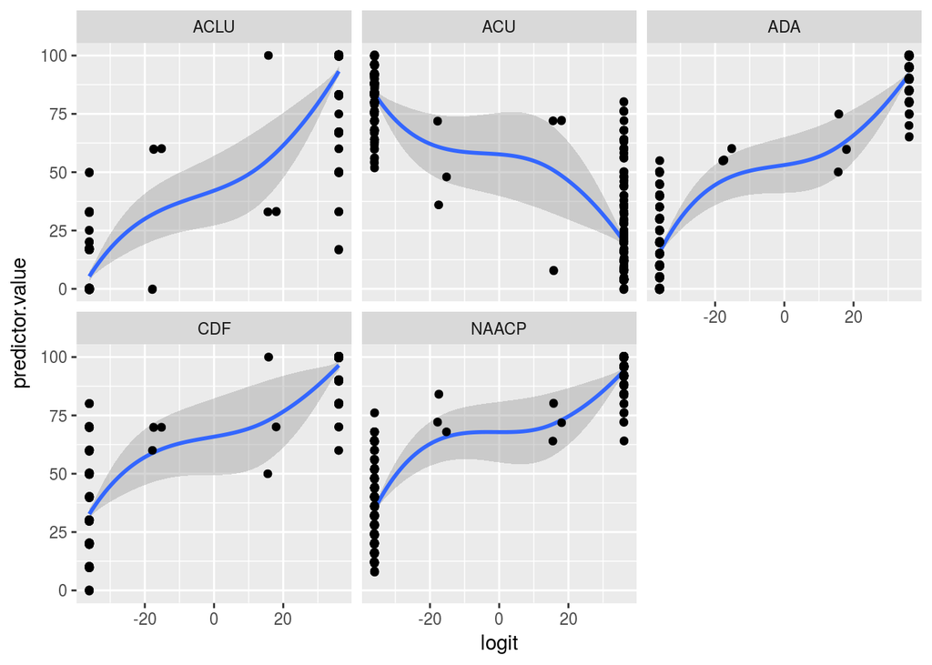

```r
# check linearity
probabilities <- predict(m7, type = "response")

# Select only numeric predictors
mydata <- voter_guide_clean %>%
select(ACLU, ADA, NAACP, CDF, ACU)
predictors <- colnames(mydata)

# Bind the logit and tidying the data for plot
mydata <- mydata %>%
  mutate(logit = log(probabilities/(1-probabilities))) %>%
  gather(key = "predictors", value = "predictor.value", -logit)
#Create the scatter plots:
ggplot(mydata, aes(logit, predictor.value))+
  geom_point() +
  geom_smooth(method = "loess") +
  geom_jitter() +
 facet_wrap(~predictors)
```

First we have to check our conditions to see if our logistic model is appropriate. We also see that a lot of the scores are the same, half on the low end (0) and other half at high end (100), which makes there appear to be some linearity. We can see however that linearity does not exactly hold. We are also unsure if we can assume independence because little is known about how these scores are given and our model has multicollinearity issues, so we can not look at the z-tests and single coefficients in logistic model because their validity rely on these assumptions that are not be met.

```r
summary(m7)
```

```
##
## Call:
## glm(formula = isDemocrat ~ ACLU + ADA + NAACP + CDF + ACU, family = binomial,
##     data = voter_guide_clean)
##
## Deviance Residuals:
##        Min          1Q      Median          3Q         Max
## -7.055e-04  -2.000e-08   2.000e-08   2.000e-08   5.981e-04
##
## Coefficients:
##              Estimate Std. Error z value Pr(>|z|)
## (Intercept) -1916.468  97688.194  -0.020    0.984
## ACLU            2.803    201.416   0.014    0.989
## ADA            41.728   2136.922   0.020    0.984
## NAACP          14.489    736.928   0.020    0.984
## CDF           -26.538   1387.993  -0.019    0.985
## ACU             2.121    317.429   0.007    0.995
##
## (Dispersion parameter for binomial family taken to be 1)
##
##     Null deviance: 4.8238e+02  on 347  degrees of freedom
## Residual deviance: 1.2713e-06  on 342  degrees of freedom
## AIC: 12
##
## Number of Fisher Scoring iterations: 25
```

```r
require(lmtest)
lrtest(m3, m5,m6, m7)
```

```
## Likelihood ratio test
##
## Model 1: isDemocrat ~ ACLU
## Model 2: isDemocrat ~ ACLU + ADA
## Model 3: isDemocrat ~ ACLU + ADA + NAACP
## Model 4: isDemocrat ~ ACLU + ADA + NAACP + CDF + ACU
##   #Df   LogLik Df   Chisq Pr(>Chisq)
## 1   2 -22.6910
## 2   3  -5.5763  1 34.2295  4.898e-09 ***
## 3   4  -5.5251  1  0.1024   0.748933
## 4   6   0.0000  2 11.0502   0.003986 **
## ---
## Signif. codes:  0 '***' 0.001 '**' 0.01 '*' 0.05 '.' 0.1 ' ' 1
```

We then used nested likelihood ratio test, we want to see that if we already have ACLU in the model, do we also need at least one of others as predictors. We have enough evidence at the 5% significance level that a lawmaker’s ADA score is a useful predictor in a model for the likelihood of being a Democrat when holding ACLU score constant, CHISQ = 34.2295 and P-value = 4.898 x 10^-9. We don’t have enough evidence at the 5% level to conclude that NAACP score is a useful predictor of a lawmakers likelihood of being a Democrat when holding ACLU and ADA scores constant, CHISQ = 0.1024 and p-value = 0.748933. Lastly we have evidence that either CDF score or ACU Score are useful predictors for the likelihood of being a Democrat, CHISQ = 11.0502 and p-value = 0.003986 .

# Discussion/Conclusion:

In conclusion, we saw that the scores were highly correlated to each other. This is because some of these scores could be based on similar metrics. We also saw that these scores from lobby organizations are related to a politician’s political party and for the most part it appears that these scores from groups fall along party line. So perhaps voters might want to take the ratings of lobbying groups with a grain of salt . Instead of using these scores to help decide a candidate it might be better for a voter to do more in depth research about a candidate.

The scores seemed to lie on the extreme end. Through looking at our data we can see that a politician would either receive a high score around 95-100 or a zero, there were very few moderate scores. This might suggest that these scores are very partisan. Our data was taken in 2007 which was a less partisan time so our conclusions might not reflect entirely what is happening today in our political climate. We also don’t know how lawmakers are influenced by these scores and do the scores reflect how these organizations give to politicians’ campaigns? We also don’t know how these scores influence each other so we could not assume independence of our observations. We also saw that these groups basis for their ratings were often not given to the public which is concerning. In future studies, we might want to study how gender and age influence these scores and party. We also want to see how these scores might differ for senators because this data was just for members in the House of Representatives who are often more extreme politically and less moderate.

# Sources:

[1] Collins, Keith. “2018 Election Calendar and Results.” The New York Times, The New York Times, 23 Jan. 2018, www.nytimes.com/interactive/2018/us/elections/calendar-primary-results.html.

[2] Flanigan, William H. “Vote Choice and Electoral Decisions.” Political Behavior of the American Electorate, pp. 209–239.

[3] Forecasterenten. “Do Voters Care About Ethics?” FiveThirtyEight, FiveThirtyEight, 11 Jan. 2017, fivethirtyeight.com/features/do-voters-care-about-ethics/.

[4] Hopkins, Douglas. “Hyper-Partisan Politics Leaves Us Deaf, Dumb and Blind to Better Ideas.” TheHill, 4 Feb. 2016, thehill.com/blogs/congress-blog/politics/233850-hyper-partisan-politics-leaves-us-deaf-dumb-and-blind-to-better.

[5] “The Center for Responsive Politics.” OpenSecrets.org, www.opensecrets.org/industries/indus.php?ind=Q. https://wiki.csc.calpoly.edu/datasets/wiki/VoterGuide

[6] “2016 Presidential Candidate Ratings and Scorecards.” Ballotpedia, ballotpedia.org/2016_presidential_candidate_ratings_and_scorecards#American_Conservative_Union.

[7] “Keeping Score: The Power of Lawmaker ‘Report Cards’.” CQ | Keeping Score: The Power of Lawmaker ‘Report Cards’, public.cq.com/docs/weeklyreport/weeklyreport-000004207216.html.